# Exploration

## Part I - Loan Data Exploration

## Introduction

### Preliminary Wrangling

This document explores a dataset containing 113,937 loans with 81 variables on each loan, including loan amount, borrower rate (or interest rate), current loan status, borrower income, and many others.

## Data Gathering

```python
#import all packages and set plots to be embedded inline
import pandas as pd
import seaborn as sns
import numpy as np
import matplotlib.pyplot as plt

%matplotlib inline
```

```python
#Read the csv file,and check its top 10 rows
lone_df = pd.read_csv('~/Desktop/Udacity_lone_data_visualization/prosperLoanData.csv')
lone_df.head(10)
```

|  | ListingKey | ListingNumber | ListingCreationDate | CreditGrade | Term | LoanStatus | ClosedDate | BorrowerAPR | BorrowerRate | LenderYield | ... | LP_ServiceFees | LP_CollectionFees | LP_GrossPrincipalLoss | LP_NetPrincipalLoss | LP_NonPrincipalRecoverypayments | PercentFunded | Recommendations | InvestmentFromFriendsCount | InvestmentFromFriendsAmount | Investors |
| --- | --- | --- | --- | --- | --- | --- | --- | --- | --- | --- | --- | --- | --- | --- | --- | --- | --- | --- | --- | --- | --- |
| 0 | 1021339766868145413AB3B | 193129 | 2007-08-26 19:09:29.263000000 | C | 36 | Completed | 2009-08-14 00:00:00 | 0.16516 | 0.1580 | 0.1380 | ... | -133.18 | 0.0 | 0.0 | 0.0 | 0.0 | 1.0 | 0 | 0 | 0.0 | 258 |
| 1 | 10273602499503308B223C1 | 1209647 | 2014-02-27 08:28:07.900000000 | NaN | 36 | Current | NaN | 0.12016 | 0.0920 | 0.0820 | ... | 0.00 | 0.0 | 0.0 | 0.0 | 0.0 | 1.0 | 0 | 0 | 0.0 | 1 |
| 2 | 0EE9337825851032864889A | 81716 | 2007-01-05 15:00:47.090000000 | HR | 36 | Completed | 2009-12-17 00:00:00 | 0.28269 | 0.2750 | 0.2400 | ... | -24.20 | 0.0 | 0.0 | 0.0 | 0.0 | 1.0 | 0 | 0 | 0.0 | 41 |
| 3 | 0EF5356002482715299901A | 658116 | 2012-10-22 11:02:35.010000000 | NaN | 36 | Current | NaN | 0.12528 | 0.0974 | 0.0874 | ... | -108.01 | 0.0 | 0.0 | 0.0 | 0.0 | 1.0 | 0 | 0 | 0.0 | 158 |
| 4 | 0F023589499656230C5E3E2 | 909464 | 2013-09-14 18:38:39.097000000 | NaN | 36 | Current | NaN | 0.24614 | 0.2085 | 0.1985 | ... | -60.27 | 0.0 | 0.0 | 0.0 | 0.0 | 1.0 | 0 | 0 | 0.0 | 20 |
| 5 | 0F05359734824199381F61D | 1074836 | 2013-12-14 08:26:37.093000000 | NaN | 60 | Current | NaN | 0.15425 | 0.1314 | 0.1214 | ... | -25.33 | 0.0 | 0.0 | 0.0 | 0.0 | 1.0 | 0 | 0 | 0.0 | 1 |
| 6 | 0F0A3576754255009D63151 | 750899 | 2013-04-12 09:52:56.147000000 | NaN | 36 | Current | NaN | 0.31032 | 0.2712 | 0.2612 | ... | -22.95 | 0.0 | 0.0 | 0.0 | 0.0 | 1.0 | 0 | 0 | 0.0 | 1 |
| 7 | 0F1035772717087366F9EA7 | 768193 | 2013-05-05 06:49:27.493000000 | NaN | 36 | Current | NaN | 0.23939 | 0.2019 | 0.1919 | ... | -69.21 | 0.0 | 0.0 | 0.0 | 0.0 | 1.0 | 0 | 0 | 0.0 | 1 |
| 8 | 0F043596202561788EA13D5 | 1023355 | 2013-12-02 10:43:39.117000000 | NaN | 36 | Current | NaN | 0.07620 | 0.0629 | 0.0529 | ... | -16.77 | 0.0 | 0.0 | 0.0 | 0.0 | 1.0 | 0 | 0 | 0.0 | 1 |
| 9 | 0F043596202561788EA13D5 | 1023355 | 2013-12-02 10:43:39.117000000 | NaN | 36 | Current | NaN | 0.07620 | 0.0629 | 0.0529 | ... | -16.77 | 0.0 | 0.0 | 0.0 | 0.0 | 1.0 | 0 | 0 | 0.0 | 1 |

10 rows × 81 columns

```python
# display the dimension of the dataset
lone_df.shape
```

```
(113937, 81)
```

## Data Assessing and Cleaning

```python
# Choose some columns from the dataset which is interested for the analysis
columns_list = ['Term','LoanStatus','BorrowerAPR','LenderYield',
                'EstimatedEffectiveYield','ProsperRating (numeric)','ProsperRating (Alpha)',
                'ListingCategory (numeric)','Occupation','EmploymentStatus','DebtToIncomeRatio',
                'IncomeRange','StatedMonthlyIncome','LoanOriginalAmount','MonthlyLoanPayment']
```

```python
# Convert the list to the dataframe
df_lone = lone_df[columns_list]
```

```python
# dsplay few sample datasets.
df_lone.sample(10)
```

|  | Term | LoanStatus | BorrowerAPR | LenderYield | EstimatedEffectiveYield | ProsperRating (numeric) | ProsperRating (Alpha) | ListingCategory (numeric) | Occupation | EmploymentStatus | DebtToIncomeRatio | IncomeRange | StatedMonthlyIncome | LoanOriginalAmount | MonthlyLoanPayment |
| --- | --- | --- | --- | --- | --- | --- | --- | --- | --- | --- | --- | --- | --- | --- | --- |
| 78294 | 36 | Completed | 0.13697 | 0.0989 | 0.09560 | 6.0 | A | 3 | Other | Full-time | 0.53 | $1-24,999 | 1166.666667 | 10000 | 326.87 |
| 71398 | 60 | Current | 0.15271 | 0.1199 | 0.11477 | 6.0 | A | 1 | Sales - Commission | Employed | 0.26 | $50,000-74,999 | 6000.000000 | 15000 | 341.22 |
| 94740 | 36 | Chargedoff | 0.13625 | 0.1050 | NaN | NaN | NaN | 3 | Other | Full-time | 0.05 | $50,000-74,999 | 5166.666667 | 5000 | 164.88 |
| 45867 | 60 | Current | 0.14965 | 0.1169 | 0.11220 | 6.0 | A | 1 | Social Worker | Employed | 0.36 | $50,000-74,999 | 4166.666667 | 15000 | 338.92 |
| 67281 | 60 | Current | 0.25451 | 0.2193 | 0.21410 | 4.0 | C | 3 | Truck Driver | Full-time | 0.30 | $75,000-99,999 | 6250.000000 | 15000 | 422.25 |
| 72696 | 36 | Current | 0.18275 | 0.1365 | 0.12898 | 5.0 | B | 1 | Other | Employed | 0.21 | $100,000+ | 12500.000000 | 25000 | 862.35 |
| 95636 | 36 | Current | 0.28339 | 0.2349 | 0.22910 | 3.0 | D | 1 | Other | Employed | 0.18 | $25,000-49,999 | 3250.000000 | 6500 | 256.69 |
| 94589 | 36 | Chargedoff | 0.25371 | 0.2059 | 0.19030 | 4.0 | C | 1 | Other | Other | 0.31 | $75,000-99,999 | 6500.000000 | 15000 | 569.68 |
| 761 | 60 | Current | 0.16499 | 0.1319 | 0.12600 | 5.0 | B | 1 | Professional | Employed | 0.14 | $75,000-99,999 | 7916.666667 | 11500 | 268.72 |
| 105287 | 36 | Current | 0.26149 | 0.2135 | 0.19571 | 3.0 | D | 1 | NaN | Other | 0.19 | $50,000-74,999 | 4166.666667 | 3000 | 115.12 |

```python
# check the null valus and data types
df_lone.info()
```

```
<class 'pandas.core.frame.DataFrame'>
RangeIndex: 113937 entries, 0 to 113936
Data columns (total 15 columns):
 #   Column                     Non-Null Count   Dtype
---  ------                     --------------   -----
 0   Term                       113937 non-null  int64
 1   LoanStatus                 113937 non-null  object
 2   BorrowerAPR                113912 non-null  float64
 3   LenderYield                113937 non-null  float64
 4   EstimatedEffectiveYield    84853 non-null   float64
 5   ProsperRating (numeric)    84853 non-null   float64
 6   ProsperRating (Alpha)      84853 non-null   object
 7   ListingCategory (numeric)  113937 non-null  int64
 8   Occupation                 110349 non-null  object
 9   EmploymentStatus           111682 non-null  object
 10  DebtToIncomeRatio          105383 non-null  float64
 11  IncomeRange                113937 non-null  object
 12  StatedMonthlyIncome        113937 non-null  float64
 13  LoanOriginalAmount         113937 non-null  int64
 14  MonthlyLoanPayment         113937 non-null  float64
dtypes: float64(7), int64(3), object(5)
memory usage: 13.0+ MB
```

```python
# chek duplicated datasets
sum(df_lone.duplicated())
```

```
1013
```

```python
# fill the missing  values in the Occuation with "Unknown"
df_lone.Occupation = df_lone.Occupation.fillna('Unknown')
```

```python
# Test the code
df_lone.info()
```

```
<class 'pandas.core.frame.DataFrame'>
RangeIndex: 113937 entries, 0 to 113936
Data columns (total 15 columns):
 #   Column                     Non-Null Count   Dtype
---  ------                     --------------   -----
 0   Term                       113937 non-null  int64
 1   LoanStatus                 113937 non-null  object
 2   BorrowerAPR                113912 non-null  float64
 3   LenderYield                113937 non-null  float64
 4   EstimatedEffectiveYield    84853 non-null   float64
 5   ProsperRating (numeric)    84853 non-null   float64
 6   ProsperRating (Alpha)      84853 non-null   object
 7   ListingCategory (numeric)  113937 non-null  int64
 8   Occupation                 113937 non-null  object
 9   EmploymentStatus           111682 non-null  object
 10  DebtToIncomeRatio          105383 non-null  float64
 11  IncomeRange                113937 non-null  object
 12  StatedMonthlyIncome        113937 non-null  float64
 13  LoanOriginalAmount         113937 non-null  int64
 14  MonthlyLoanPayment         113937 non-null  float64
dtypes: float64(7), int64(3), object(5)
memory usage: 13.0+ MB
```

```python
# Calculate the mean value for the 'DebtToIncomeRatio'
mean = df_lone['DebtToIncomeRatio'].mean()
```

```python
# filling the null value wit he mean
df_lone['DebtToIncomeRatio'].fillna(mean,inplace= True)
```

```python
#test the code
df_lone.info()
```

```
<class 'pandas.core.frame.DataFrame'>
RangeIndex: 113937 entries, 0 to 113936
Data columns (total 15 columns):
 #   Column                     Non-Null Count   Dtype
---  ------                     --------------   -----
 0   Term                       113937 non-null  int64
 1   LoanStatus                 113937 non-null  object
 2   BorrowerAPR                113912 non-null  float64
 3   LenderYield                113937 non-null  float64
 4   EstimatedEffectiveYield    84853 non-null   float64
 5   ProsperRating (numeric)    84853 non-null   float64
 6   ProsperRating (Alpha)      84853 non-null   object
 7   ListingCategory (numeric)  113937 non-null  int64
 8   Occupation                 113937 non-null  object
 9   EmploymentStatus           111682 non-null  object
 10  DebtToIncomeRatio          113937 non-null  float64
 11  IncomeRange                113937 non-null  object
 12  StatedMonthlyIncome        113937 non-null  float64
 13  LoanOriginalAmount         113937 non-null  int64
 14  MonthlyLoanPayment         113937 non-null  float64
dtypes: float64(7), int64(3), object(5)
memory usage: 13.0+ MB
```

```python
# selecting rows only where ProsperRating is not null
df_lone = df_lone[df_lone['ProsperRating (Alpha)'].notnull()]
```

```python
#test the code
df_lone.info()
```

```
<class 'pandas.core.frame.DataFrame'>
Int64Index: 84853 entries, 1 to 113936
Data columns (total 15 columns):
 #   Column                     Non-Null Count  Dtype
---  ------                     --------------  -----
 0   Term                       84853 non-null  int64
 1   LoanStatus                 84853 non-null  object
 2   BorrowerAPR                84853 non-null  float64
 3   LenderYield                84853 non-null  float64
 4   EstimatedEffectiveYield    84853 non-null  float64
 5   ProsperRating (numeric)    84853 non-null  float64
 6   ProsperRating (Alpha)      84853 non-null  object
 7   ListingCategory (numeric)  84853 non-null  int64
 8   Occupation                 84853 non-null  object
 9   EmploymentStatus           84853 non-null  object
 10  DebtToIncomeRatio          84853 non-null  float64
 11  IncomeRange                84853 non-null  object
 12  StatedMonthlyIncome        84853 non-null  float64
 13  LoanOriginalAmount         84853 non-null  int64
 14  MonthlyLoanPayment         84853 non-null  float64
dtypes: float64(7), int64(3), object(5)
memory usage: 10.4+ MB
```

```python
print(df_lone.shape)
df_lone.head(10)
```

```
(84853, 15)
```

|  | Term | LoanStatus | BorrowerAPR | LenderYield | EstimatedEffectiveYield | ProsperRating (numeric) | ProsperRating (Alpha) | ListingCategory (numeric) | Occupation | EmploymentStatus | DebtToIncomeRatio | IncomeRange | StatedMonthlyIncome | LoanOriginalAmount | MonthlyLoanPayment |
| --- | --- | --- | --- | --- | --- | --- | --- | --- | --- | --- | --- | --- | --- | --- | --- |
| 1 | 36 | Current | 0.12016 | 0.0820 | 0.07960 | 6.0 | A | 2 | Professional | Employed | 0.18 | $50,000-74,999 | 6125.000000 | 10000 | 318.93 |
| 3 | 36 | Current | 0.12528 | 0.0874 | 0.08490 | 6.0 | A | 16 | Skilled Labor | Employed | 0.15 | $25,000-49,999 | 2875.000000 | 10000 | 321.45 |
| 4 | 36 | Current | 0.24614 | 0.1985 | 0.18316 | 3.0 | D | 2 | Executive | Employed | 0.26 | $100,000+ | 9583.333333 | 15000 | 563.97 |
| 5 | 60 | Current | 0.15425 | 0.1214 | 0.11567 | 5.0 | B | 1 | Professional | Employed | 0.36 | $100,000+ | 8333.333333 | 15000 | 342.37 |
| 6 | 36 | Current | 0.31032 | 0.2612 | 0.23820 | 2.0 | E | 1 | Sales - Retail | Employed | 0.27 | $25,000-49,999 | 2083.333333 | 3000 | 122.67 |
| 7 | 36 | Current | 0.23939 | 0.1919 | 0.17830 | 4.0 | C | 2 | Laborer | Employed | 0.24 | $25,000-49,999 | 3355.750000 | 10000 | 372.60 |
| 8 | 36 | Current | 0.07620 | 0.0529 | 0.05221 | 7.0 | AA | 7 | Food Service | Employed | 0.25 | $25,000-49,999 | 3333.333333 | 10000 | 305.54 |
| 9 | 36 | Current | 0.07620 | 0.0529 | 0.05221 | 7.0 | AA | 7 | Food Service | Employed | 0.25 | $25,000-49,999 | 3333.333333 | 10000 | 305.54 |
| 10 | 60 | Current | 0.27462 | 0.2389 | 0.23320 | 4.0 | C | 1 | Fireman | Employed | 0.12 | $75,000-99,999 | 7500.000000 | 13500 | 395.37 |
| 12 | 36 | Past Due (1-15 days) | 0.17969 | 0.1335 | 0.12640 | 5.0 | B | 1 | Sales - Retail | Employed | 0.18 | $25,000-49,999 | 2416.666667 | 4000 | 137.39 |

### Exploratory Data Analysis

#### What is the structure of the dataset?

The dataset contains **84,853** loans with **15** features ('Term', 'LoanStatus', 'BorrowerAPR', 'LenderYield', 'EstimatedEffectiveYield', 'ProsperRating (numeric)', 'ProsperRating (Alpha)', 'ListingCategory (numeric)', 'Occupation', 'EmploymentStatus', 'DebtToIncomeRatio', 'IncomeRange', 'StatedMonthlyIncome', 'LoanOriginalAmount', 'MonthlyLoanPayment')

## What is/are the main feature(s) of interest in your dataset?

What i'm intersted in this dataset is what factors affect the lone outcome status and the borrower's Annual Percentage Rate (APR) rate beside to this are the difference between loan depending on how large the origional loan amount was?

### What features in the dataset do you think will help support your investigation into your feature(s) of interest?

I have seen that the total loan amount will have a great effect on the borrower's Annual Percentage Rate (APR) of the loan which the most larger the total loan amount, the most the lower the borrower's Annual Percentage Rate (APR). I also clearly seen that the borrowers stated monthly income, loan term, Prosper rating, employment status will also have effects on the APR.

## Univariate Exploration

Let's start by looking at the distribution of the main variable of interest

Categorical

- LoanStatus
- EmploymentStatus
- ProsperRating

Numerical

- Borrower APR
- DebtToIncomeRatio
- MonthlyLoanPayment
- LoanOriginalAmount

## LoanStatus Distribution

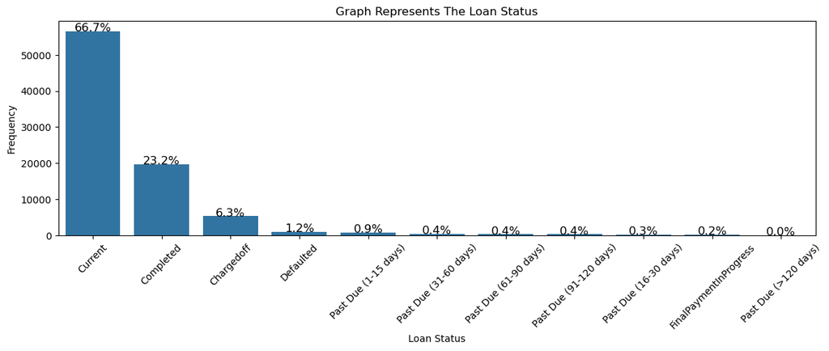

```python
def loneStatus_bar_graph():
    base_color = sns.color_palette()[0]
    type_order = df_lone['LoanStatus'].value_counts().index

    sns.countplot(data=df_lone,x='LoanStatus',color = base_color,order= type_order);
    type_count = df_lone['LoanStatus'].value_counts()
    n_count = df_lone['LoanStatus'].value_counts().sum()
    locs, labels = plt.xticks(rotation=45)

    for loc, label in zip(locs, labels):
        count = type_count[label.get_text()]
        pct_string ='{:0.1f}%'.format(100*count/n_count)
        plt.text(loc,count+1,pct_string,ha='center',color ='black',fontsize=12);
    from matplotlib import rcParams
    rcParams['figure.figsize'] = 14,5
    plt.xlabel("Loan Status")
    plt.ylabel("Frequency")
    plt.title("Graph Represents The Loan Status");
loneStatus_bar_graph()
```

As we can see from the categorical lone status graph the current lone satus is 66.7% which is the hightst distrubtion the completed and the chargedoff is the second and the thired heigest distribution respectively.

## EmploymentStatus Distribution

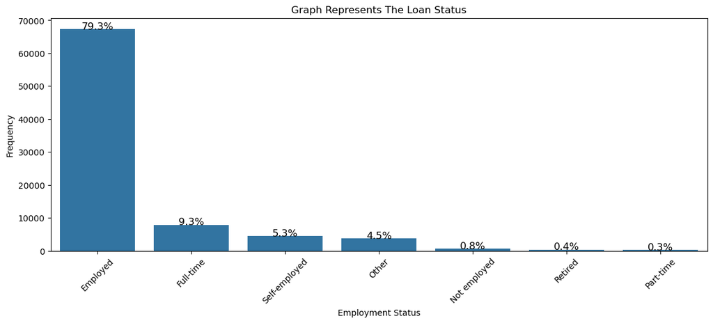

```python
def employmentStatus_bar_grap():
    base_color = sns.color_palette()[0]
    type_order = df_lone['EmploymentStatus'].value_counts().index

    sns.countplot(data=df_lone,x='EmploymentStatus',color = base_color,order= type_order);
    type_count = df_lone['EmploymentStatus'].value_counts()
    n_count = df_lone['EmploymentStatus'].value_counts().sum()
    locs, labels = plt.xticks(rotation=45)

    for loc, label in zip(locs, labels):
        count = type_count[label.get_text()]
        pct_string ='{:0.1f}%'.format(100*count/n_count)
        plt.text(loc,count+1,pct_string,ha='center',color ='black',fontsize=12);
    from matplotlib import rcParams
    rcParams['figure.figsize'] = 14,4
    plt.xlabel("Employment Status")
    plt.ylabel("Frequency")
    plt.title("Graph Represents The Loan Status");
employmentStatus_bar_grap()
```

As we see from the distribution of the employment status bar grap employed is 79.3% and full-time and self-employed is 9.3% and 5.3% respectively.

I need to replace on the EmploymentStatus columns the 'Employed' values to full-time and see the distribution.

```python
df_lone['EmploymentStatus'].unique()
```

```
array(['Employed', 'Other', 'Full-time', 'Self-employed', 'Not employed',
       'Retired', 'Part-time'], dtype=object)
```

```python
# replac Employed by Full-time
df_lone['EmploymentStatus'] = df_lone['EmploymentStatus'].replace(['Employed'],'Full-time')
```

```python
# Test the code
df_lone['EmploymentStatus'].unique()
```

```
array(['Full-time', 'Other', 'Self-employed', 'Not employed', 'Retired',
       'Part-time'], dtype=object)
```

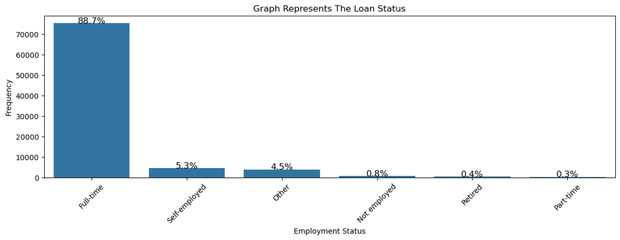

```python
def employmentStatus_bar_grap():
    base_color = sns.color_palette()[0]
    type_order = df_lone['EmploymentStatus'].value_counts().index

    sns.countplot(data=df_lone,x='EmploymentStatus',color = base_color,order= type_order);
    type_count = df_lone['EmploymentStatus'].value_counts()
    n_count = df_lone['EmploymentStatus'].value_counts().sum()
    locs, labels = plt.xticks(rotation=45)

    for loc, label in zip(locs, labels):
        count = type_count[label.get_text()]
        pct_string ='{:0.1f}%'.format(100*count/n_count)
        plt.text(loc,count+1,pct_string,ha='center',color ='black',fontsize=12);
    from matplotlib import rcParams
    rcParams['figure.figsize'] = 14,4
    plt.xlabel("Employment Status")
    plt.ylabel("Frequency")
    plt.title("Graph Represents The Loan Status");
employmentStatus_bar_grap()
```

Afte the replacing the Emolyed value by Full-time the distribtion of the employment status is 88.7% is full time employed and the other are self-employed, other,not employes,retired ,part time [5.3,4.5,0.8,0.4,0.3]% respectively

## ProsperRating Distribution

```python
 df_lone['ProsperRating (Alpha)'].unique()
```

```
array(['A', 'D', 'B', 'E', 'C', 'AA', 'HR'], dtype=object)
```

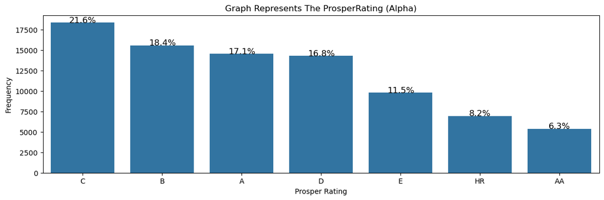

```python
def prosperRationgAlpha_bar_grap():
    base_color = sns.color_palette()[0]
    type_order = df_lone['ProsperRating (Alpha)'].value_counts().index

    sns.countplot(data=df_lone,x='ProsperRating (Alpha)',color = base_color,order= type_order);
    type_count = df_lone['ProsperRating (Alpha)'].value_counts()
    n_count = df_lone['ProsperRating (Alpha)'].value_counts().sum()
    locs, labels = plt.xticks(rotation=0)

    for loc, label in zip(locs, labels):
        count = type_count[label.get_text()]
        pct_string ='{:0.1f}%'.format(100*count/n_count)
        plt.text(loc,count+1,pct_string,ha='center',color ='black',fontsize=12);
    from matplotlib import rcParams
    rcParams['figure.figsize'] = 14,4
    plt.xlabel("Prosper Rating")
    plt.ylabel("Frequency")
    plt.title("Graph Represents The ProsperRating (Alpha)");
prosperRationgAlpha_bar_grap()
```

From the prosper rating grade **C** is the highst rating which is 21.6% the seond and the thrired ratinr is **B** and **A** with 18.4% and 17.1% respectively the last is **AA** with 6.3%

### Discuss the distribution(s) of your variable(s) of interest. Were there any unusual points? Did you need to perform any transformations?

1. **LoanStatus:**From the categorical lone status graph more of the lone is current status which is 66.7%.
2. **EmploymentStatus:**From the employe status graph most of the them are full time employee
3. **ProsperRating:**From the prosper grading graph the C rating is more frequent .

### Of the features you investigated, were there any unusual distributions? Did you perform any operations on the data to tidy, adjust, or change the form of the data? If so, why did you do this?

## BorrowerAPR Distribution

```python
# descriptive statistics for numeric variables
df_lone.describe()
```

|  | Term | BorrowerAPR | LenderYield | EstimatedEffectiveYield | ProsperRating (numeric) | ListingCategory (numeric) | DebtToIncomeRatio | StatedMonthlyIncome | LoanOriginalAmount | MonthlyLoanPayment |
| --- | --- | --- | --- | --- | --- | --- | --- | --- | --- | --- |
| count | 84853.000000 | 84853.000000 | 84853.000000 | 84853.000000 | 84853.000000 | 84853.000000 | 84853.000000 | 8.485300e+04 | 84853.000000 | 84853.000000 |
| mean | 42.486135 | 0.226658 | 0.186017 | 0.168661 | 4.072243 | 3.312647 | 0.260230 | 5.931175e+03 | 9083.440515 | 291.930720 |
| std | 11.640346 | 0.079916 | 0.074631 | 0.068467 | 1.673227 | 4.364277 | 0.304371 | 8.239944e+03 | 6287.860058 | 186.678314 |
| min | 12.000000 | 0.045830 | 0.030000 | -0.182700 | 1.000000 | 0.000000 | 0.000000 | 0.000000e+00 | 1000.000000 | 0.000000 |
| 25% | 36.000000 | 0.163280 | 0.125900 | 0.115670 | 3.000000 | 1.000000 | 0.160000 | 3.434000e+03 | 4000.000000 | 157.330000 |
| 50% | 36.000000 | 0.219450 | 0.177500 | 0.161500 | 4.000000 | 1.000000 | 0.240000 | 5.000000e+03 | 7500.000000 | 251.940000 |
| 75% | 60.000000 | 0.292540 | 0.247400 | 0.224300 | 5.000000 | 3.000000 | 0.310000 | 7.083333e+03 | 13500.000000 | 388.350000 |
| max | 60.000000 | 0.423950 | 0.340000 | 0.319900 | 7.000000 | 20.000000 | 10.010000 | 1.750003e+06 | 35000.000000 | 2251.510000 |

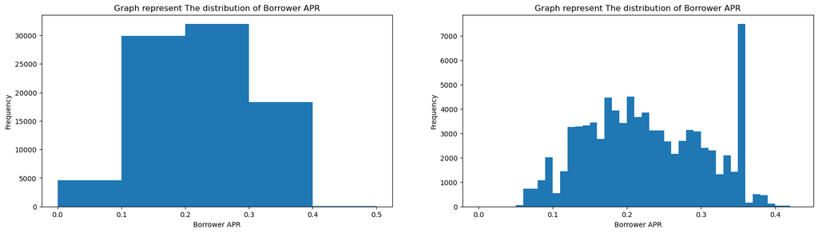

```python
def BorrowerAPR_graph():
    plt.figure(figsize=[20, 5])
    # histogram on left, example of too-large bin size
    plt.subplot(1,2,1)
    bins = np.arange(0,df_lone['BorrowerAPR'].max()+0.1,0.1)
    plt.hist(data = df_lone, x = 'BorrowerAPR', bins = bins);
    plt.xlabel('Borrower APR')
    plt.ylabel("Frequency")
    plt.title("Graph represent The distribution of Borrower APR");
    # histogram on left, example of too-small bin size
    plt.subplot(1,2,2)
    bins = np.arange(0,df_lone['BorrowerAPR'].max()+0.01,0.01)
    plt.hist(data = df_lone, x = 'BorrowerAPR', bins = bins);
    plt.xlabel('Borrower APR')
    plt.ylabel("Frequency")

    plt.title("Graph represent The distribution of Borrower APR")
BorrowerAPR_graph()
```

I polt two grap for the borrow APR with different bins to interprat the distribution more clearly,So the distribtion looks multimodal the first peack at 0.1,a large peack at 0.2.Ther is also a small peak at 0.3 wich is greater peack compare to peack at 0.1 finally a very shape peak between 0.35 and 0.36 Only very few loans have APR greater than 0.40

## DebtToIncomeRatio Distribution

```python
df_lone.DebtToIncomeRatio.describe()
```

```
count    84853.000000
mean         0.260230
std          0.304371
min          0.000000
25%          0.160000
50%          0.240000
75%          0.310000
max         10.010000
Name: DebtToIncomeRatio, dtype: float64
```

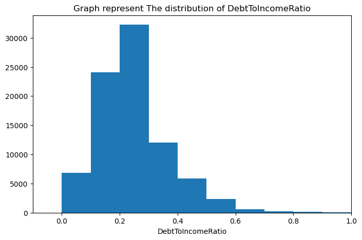

```python
# distribution plot
def debetToIncomeRation_hist_graph():
    plt.figure(figsize = [8,5])
    bin_edges = np.arange(0, df_lone['DebtToIncomeRatio'].max()+1, 0.1)
    sns.distplot(df_lone['DebtToIncomeRatio'], bins = bin_edges, kde = False,hist_kws = {'alpha' : 1})
    plt.xlim(-.1, 1)
    plt.title("Graph represent The distribution of DebtToIncomeRatio");
debetToIncomeRation_hist_graph()
```

As we can see from the plot the DebtToIncomeRation is unimodal with the highest peack point between 0.2-0.3 the distribtution is righ skewed

## Monthly Loan Payment Distribution

```python
df_lone.MonthlyLoanPayment.describe()
```

```
count    84853.000000
mean       291.930720
std        186.678314
min          0.000000
25%        157.330000
50%        251.940000
75%        388.350000
max       2251.510000
Name: MonthlyLoanPayment, dtype: float64
```

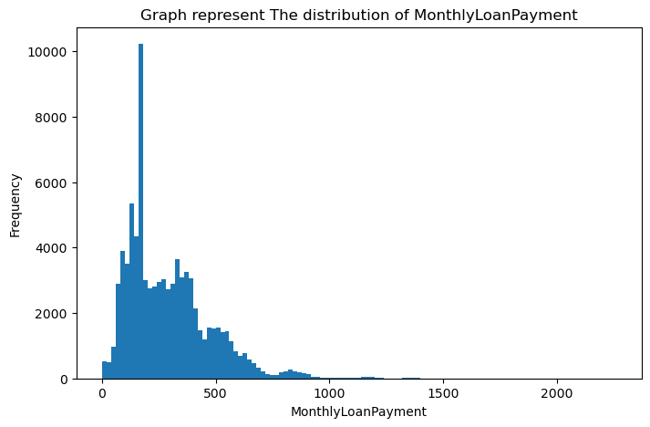

```python
def monthlyLoanPayment_hist_grap():
    plt.figure(figsize = [8,5])
    bins = np.arange(0,df_lone['MonthlyLoanPayment'].max()+20,20)
    plt.hist(data = df_lone, x = 'MonthlyLoanPayment', bins = bins);
    plt.xlabel('MonthlyLoanPayment')
    plt.ylabel("Frequency")
    plt.title("Graph represent The distribution of MonthlyLoanPayment")
monthlyLoanPayment_hist_grap()
```

AS we can see from the grape the distribution is right skewed to inteperate clearly we need to transform the dat using log transformation scale.

```python
np.log10(df_lone['MonthlyLoanPayment'].describe())
```

```
count    4.928667
mean     2.465280
std      2.271094
min          -inf
25%      2.196812
50%      2.401297
75%      2.589223
max      3.352474
Name: MonthlyLoanPayment, dtype: float64
```

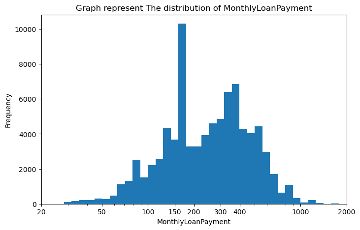

```python
def monthlyLoanPayment_hist_grap():
    plt.figure(figsize = [8,5])
    bins = 10**np.arange(0,3.35,0.05)
    ticks=[10,20,50,100,150,200,300,400,1000,2000]
    labels = ['{}'.format(v) for v in ticks]
    plt.xscale('log')
    plt.hist(data = df_lone, x = 'MonthlyLoanPayment', bins = bins);
    plt.xticks(ticks, labels)
    plt.xlim((20,2000))
    plt.xlabel('MonthlyLoanPayment')
    plt.ylabel("Frequency")
    plt.title("Graph represent The distribution of MonthlyLoanPayment")
monthlyLoanPayment_hist_grap()
```

Now i can see clearly the distribution of the monthly loan payment their is a large peack between 150-200

## LoanOriginalAmount Distribution

```python
df_lone.LoanOriginalAmount.describe()
```

```
count    84853.000000
mean      9083.440515
std       6287.860058
min       1000.000000
25%       4000.000000
50%       7500.000000
75%      13500.000000
max      35000.000000
Name: LoanOriginalAmount, dtype: float64
```

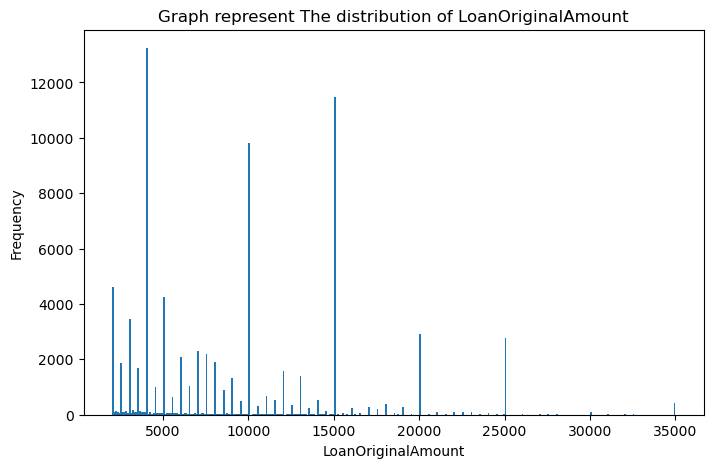

```python
def LoanOriginalAmount_hist_grap():
    plt.figure(figsize = [8,5])
    bins = np.arange(2000,df_lone['LoanOriginalAmount'].max()+100,100)
    plt.hist(data = df_lone, x = 'LoanOriginalAmount', bins = bins);
    plt.xlabel('LoanOriginalAmount')
    plt.ylabel("Frequency")
    plt.title("Graph represent The distribution of LoanOriginalAmount")
LoanOriginalAmount_hist_grap()
```

I have see the distribution of the lone original amount is right skewed some data are distorted it hard to interperate so log transformation is needed to normalize.

```python
 np.log10(df_lone['LoanOriginalAmount']).describe()
```

```
count    84853.000000
mean         3.849628
std          0.319966
min          3.000000
25%          3.602060
50%          3.875061
75%          4.130334
max          4.544068
Name: LoanOriginalAmount, dtype: float64
```

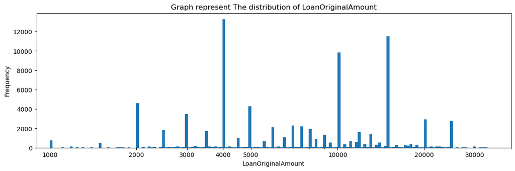

```python
def transformedLoanOriginalAmount_hist_grap():
    bins = 10**np.arange(3,4.5+0.04,0.01)
    ticks=[1000,2000,3000,4000,5000,10000,20000,30000]
    labels = ['{}'.format(v) for v in ticks]
    plt.hist(data = df_lone, x = 'LoanOriginalAmount', bins = bins)
    plt.xscale('log')
    plt.xticks(ticks, labels)
    plt.xlim((900,40000))
    plt.xlabel('LoanOriginalAmount')
    plt.ylabel("Frequency")
    plt.title("Graph represent The distribution of LoanOriginalAmount")

transformedLoanOriginalAmount_hist_grap()
```

### Discuss the distribution(s) of your variable(s) of interest. Were there any unusual points? Did you need to perform any transformations?

In the numerical disribution analysis i choose four variables **BorrowerAPR,DebtToIncomeRatio,MonthlyLoanPayment and LoneOriginalAmount.**

- The distribution of borrowers APR looks multimodal. Most of the values are at the range of 0.05 and 0.45. There are no unusual points and no need to perform any transformations.
- The plot the DebtToIncomeRation is unimodal with the highest peack point between 0.2-0.3 the distribtution is righ skewed
- After the log transformation scale the distribution of the monthly loan payment isa large peack between 150-200
- The lone origional amout is a mutlimodel distribution with a multiple peack and values xk multiple.

### Of the features you investigated, were there any unusual distributions? Did you perform any operations on the data to tidy, adjust, or change the form of the data? If so, why did you do this?

```python
df_lone.columns
```

```
Index(['Term', 'LoanStatus', 'BorrowerAPR', 'LenderYield',
       'EstimatedEffectiveYield', 'ProsperRating (numeric)',
       'ProsperRating (Alpha)', 'ListingCategory (numeric)', 'Occupation',
       'EmploymentStatus', 'DebtToIncomeRatio', 'IncomeRange',
       'StatedMonthlyIncome', 'LoanOriginalAmount', 'MonthlyLoanPayment'],
      dtype='object')
```

## Bivariate Exploration

To start off with, I want to look at the pairwise correlations present between features in the data.

```python
quantitative_vars = ['LoanOriginalAmount', 'BorrowerAPR','DebtToIncomeRatio', 'MonthlyLoanPayment']
qualitative_vars = [ 'ProsperRating (Alpha)', 'EmploymentStatus','LoanStatus']
```

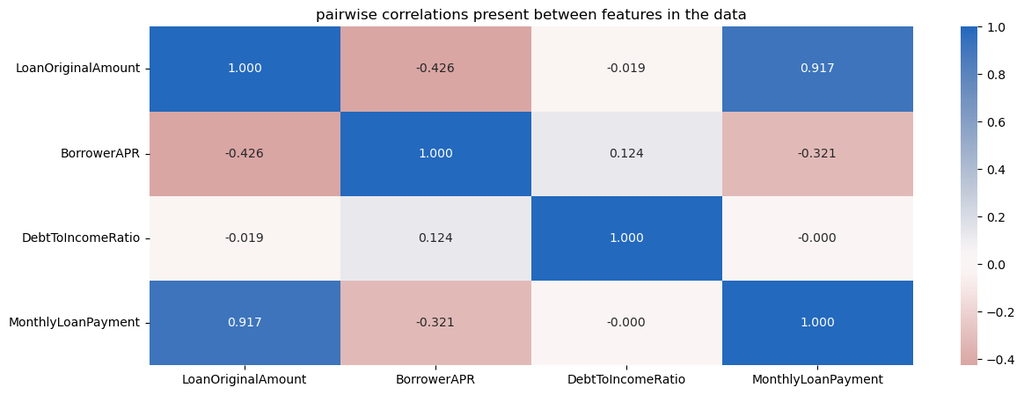

```python
# correlation plot
plt.figure(figsize = [14, 5])
sns.heatmap(df_lone[quantitative_vars].corr(), annot = True, fmt = '.3f',cmap = 'vlag_r', center = 0);
plt.title("pairwise correlations present between features in the data")
```

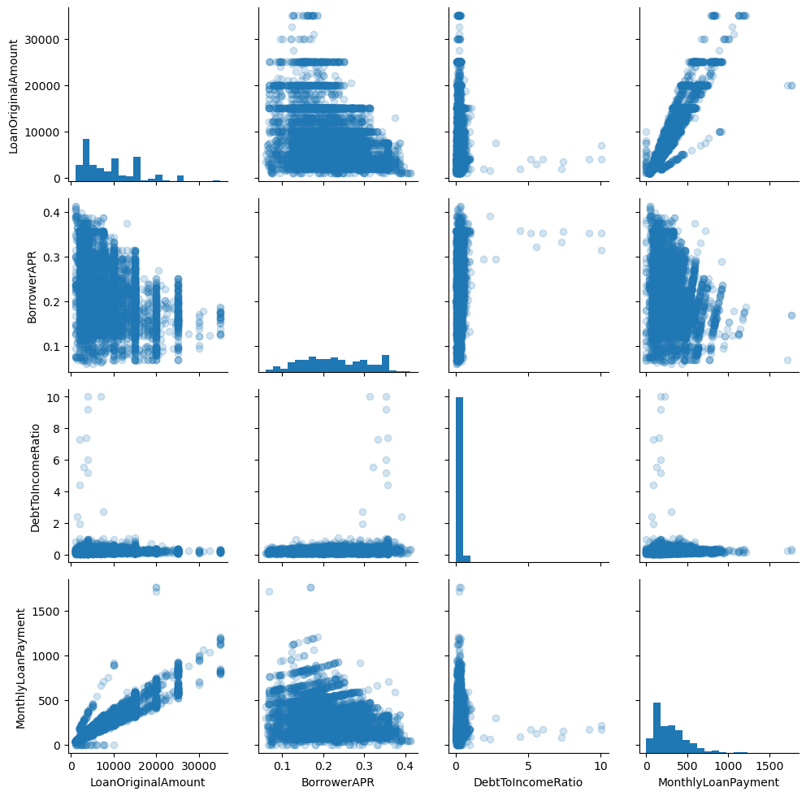

```python
# plot matrix: sample 5000 loans so that plots are clearer and render faster
loan_data = df_lone.sample(5000)
g = sns.PairGrid(data = loan_data.dropna(), vars = quantitative_vars)
g = g.map_diag(plt.hist, bins=20)
g.map_offdiag(plt.scatter, alpha=0.2);
```

Let's move on to looking at how borrower APR, DebtToIncomeRatio and loan original amount correlate with the categorical variables.

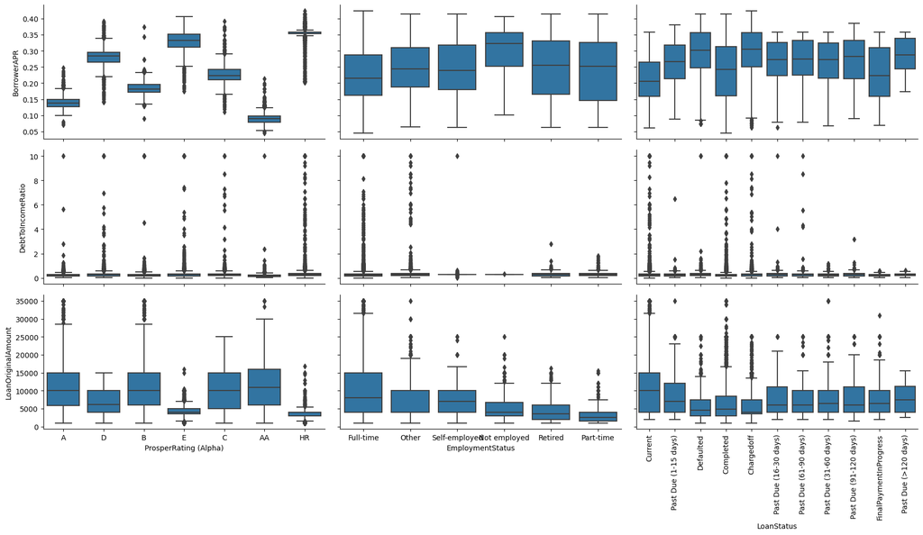

```python
# plot matrix of numeric features against categorical features.
def boxgrid(x,y,**kwargs):
    default_color = sns.color_palette()[0]
    sns.boxplot(x, y, color = default_color)

plt.figure(figsize = [14, 10])
g = sns.PairGrid(data = df_lone, x_vars = [ 'ProsperRating (Alpha)', 'EmploymentStatus','LoanStatus'], y_vars = ['BorrowerAPR', 'DebtToIncomeRatio', 'LoanOriginalAmount'], height = 3, aspect = 2)
g.map(boxgrid);
plt.xticks(rotation=90);
```

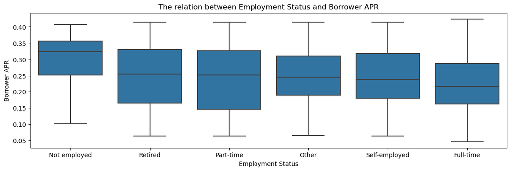

```python
# display boxplot
base_color=sns.color_palette()[0]
sns.boxplot(data=df_lone,x="EmploymentStatus",y="BorrowerAPR",color=base_color,order= index_order)
plt.xlabel("Employment Status");
plt.ylabel("Borrower APR");
plt.title("The relation between Employment Status and Borrower APR");
```

As we can see from the plot the following poits are my conclusion.

- The Not employeds are more Borrower APR.
- Peoples workind as full time jobs are less borriwer APR.

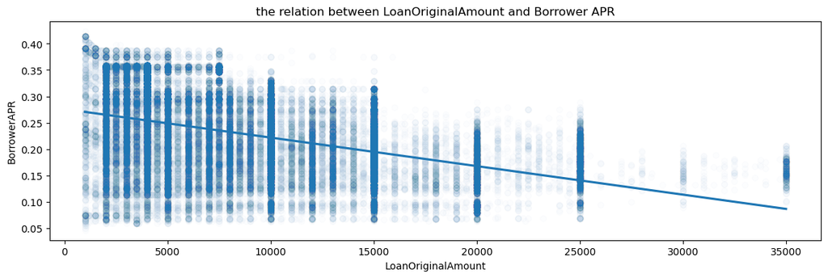

```python
# diplay the Scatter plot
sns.regplot(data = df_lone, x = 'LoanOriginalAmount', y = 'BorrowerAPR', scatter_kws={'alpha':0.01})
plt.title("the relation between LoanOriginalAmount and Borrower APR");
```

### Talk about some of the relationships you observed in this part of the investigation. How did the feature(s) of interest vary with other features in the dataset?

The borrower APR is negatively associated with the loan original amount, which mean the more the loan amount, the lower the borrower APR. It also shows that at different size of the loan amount and the borrower APR has a large range, but the range of borrower APR decrease with the increase of loan amount.

## Multivariate Exploration

The main thing I want to explore in this part of the analysis is how the categorical variable (Prosper rating and EmploymentStatus) play into the relationship between borrower APR and loan original amount.

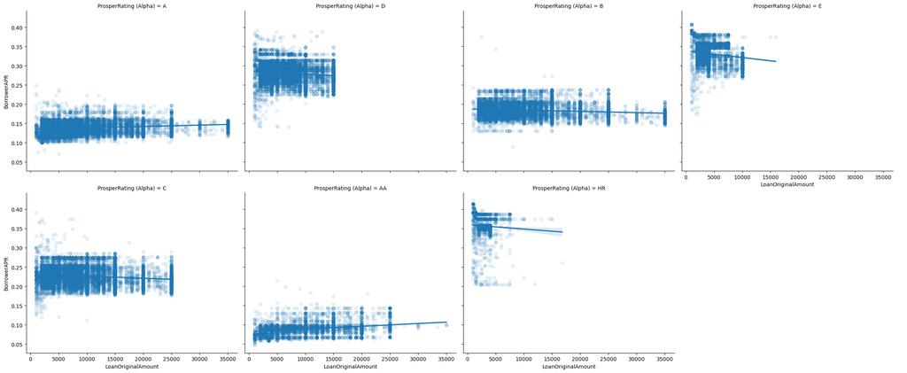

```python
# Term effect on relationship of APR and loan amount
g=sns.FacetGrid(data=df_lone, aspect=1.2, height=5, col='ProsperRating (Alpha)', col_wrap=4)
g.map(sns.regplot, 'LoanOriginalAmount', 'BorrowerAPR', x_jitter=0.04, scatter_kws={'alpha':0.1});
g.add_legend();
```

I can make the following poits after the plot

1. The loan amount increases with better rating.
2. The borrower APR decreases with better rating.
3. Interestingly, the relationship between borrower APR and loan amount turns from negative to slightly positive when the Prosper ratings are increased from HR to A or better.
4. This may because people with A or AA ratings tend to borrow more money, increasting APR could prevent them borrow even more and maximize the profit.
5. On the oter side people with lower ratings tend to borrow less money, decreasing APR could encourage them to borrow more.

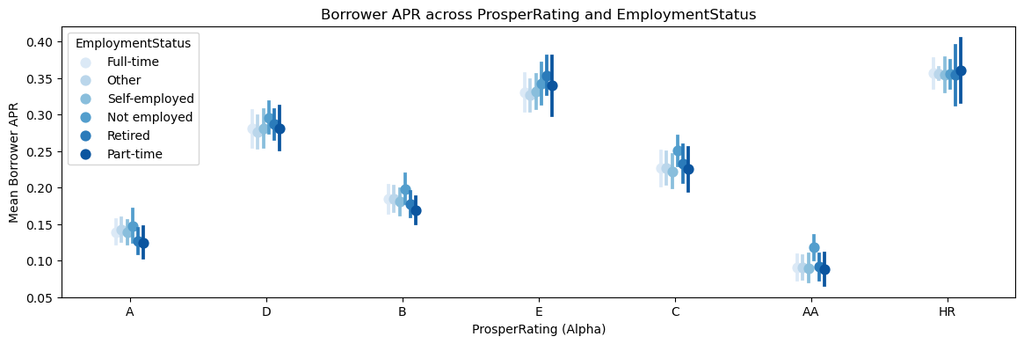

```python
#The relation between ProsperRating (Alpha) , BorrowerAPR & EmploymentStatus
ax = sns.pointplot(data = df_lone, x = 'ProsperRating (Alpha)', y = 'BorrowerAPR', hue = 'EmploymentStatus',
           palette = 'Blues', linestyles = '', dodge = 0.2, ci='sd')
plt.title('Borrower APR across ProsperRating and EmploymentStatus')
plt.ylabel('Mean Borrower APR')
ax.set_yticklabels([],minor = True);
```